# Project2

nkvasg

Sunday, March 22, 2015

## Overview

Load the ToothGrowth data and perform some basic exploratory data analyses

Provide a basic summary of the data. Use confidence intervals and/or hypothesis tests to compare tooth growth by supp and dose. (Only use the techniques from class, even if there’s other approaches worth considering) State your conclusions and the assumptions needed for your conclusions.

## Load and Inspect Data

```r
# load neccesary libraries
library(ggplot2)
library(datasets)

# The Effect of Vitamin C on Tooth Growth in Guinea Pigs
data(ToothGrowth)
head(ToothGrowth)
```

```
##    len supp dose
## 1  4.2   VC  0.5
## 2 11.5   VC  0.5
## 3  7.3   VC  0.5
## 4  5.8   VC  0.5
## 5  6.4   VC  0.5
## 6 10.0   VC  0.5
```

```r
dim(ToothGrowth)
```

```
## [1] 60  3
```

```r
summary(ToothGrowth)
```

```
##       len        supp         dose
##  Min.   : 4.20   OJ:30   Min.   :0.500
##  1st Qu.:13.07   VC:30   1st Qu.:0.500
##  Median :19.25           Median :1.000
##  Mean   :18.81           Mean   :1.167
##  3rd Qu.:25.27           3rd Qu.:2.000
##  Max.   :33.90           Max.   :2.000
```

```r
str(ToothGrowth)
```

```
## 'data.frame':    60 obs. of  3 variables:
##  $ len : num  4.2 11.5 7.3 5.8 6.4 10 11.2 11.2 5.2 7 ...
##  $ supp: Factor w/ 2 levels "OJ","VC": 2 2 2 2 2 2 2 2 2 2 ...
##  $ dose: num  0.5 0.5 0.5 0.5 0.5 0.5 0.5 0.5 0.5 0.5 ...
```

```r
table(ToothGrowth$supp, ToothGrowth$dose)
```

```
##
##      0.5  1  2
##   OJ  10 10 10
##   VC  10 10 10
```

## Plotting

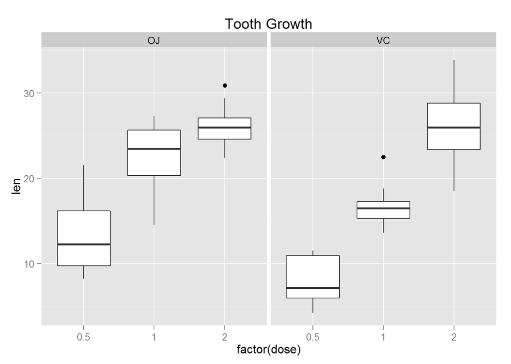

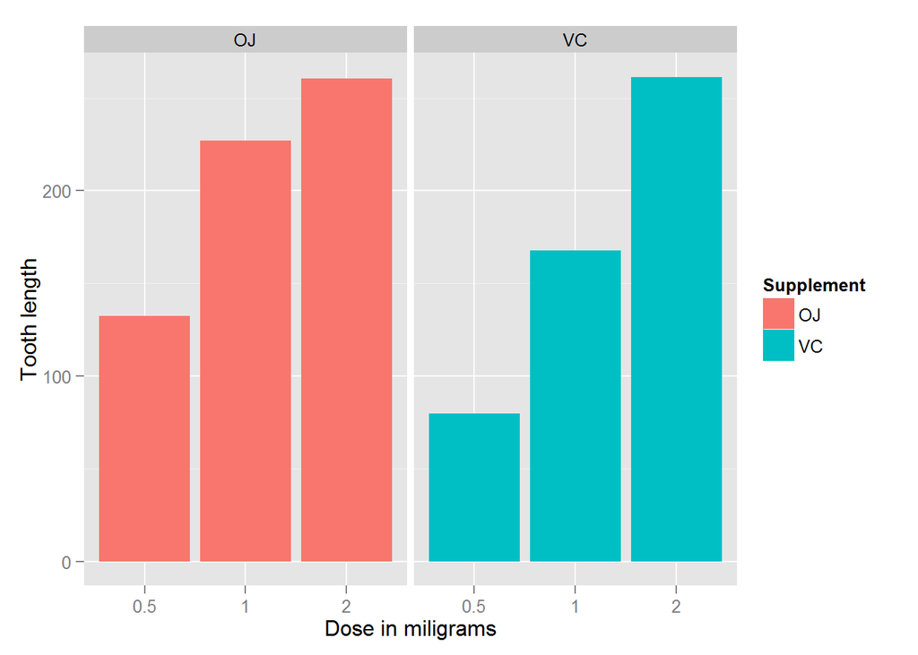

The bar graph above indicates that the tooth length increases with increasing dosage for both OJ and VC supplement types. We will use a t-test to compare tooth growth by two supplement methods at each dosage.

## Testing to compare tooth growth by supp at different dosage

### Compare Supp at Dosage = 0.5 mg

```r
test1 <- t.test(len ~ supp, paired=F, var.equal=T, data = ToothGrowth[ToothGrowth$dose == 0.5,1:2])
test1
```

```
##
##  Two Sample t-test
##
## data:  len by supp
## t = 3.1697, df = 18, p-value = 0.005304
## alternative hypothesis: true difference in means is not equal to 0
## 95 percent confidence interval:
##  1.770262 8.729738
## sample estimates:
## mean in group OJ mean in group VC
##            13.23             7.98
```

### Compare Supp at Dosage = 1 mg

```r
test2 <- t.test(len ~ supp, paired=F, var.equal=T, data = ToothGrowth[ToothGrowth$dose == 1,1:2])
test2
```

```
##
##  Two Sample t-test
##
## data:  len by supp
## t = 4.0328, df = 18, p-value = 0.0007807
## alternative hypothesis: true difference in means is not equal to 0
## 95 percent confidence interval:
##  2.840692 9.019308
## sample estimates:
## mean in group OJ mean in group VC
##            22.70            16.77
```

### Compare Supp at Dosage = 2 mg

```r
test3 <- t.test(len ~ supp, paired=F, var.equal=T, data = ToothGrowth[ToothGrowth$dose == 2,1:2])
test3
```

```
##
##  Two Sample t-test
##
## data:  len by supp
## t = -0.0461, df = 18, p-value = 0.9637
## alternative hypothesis: true difference in means is not equal to 0
## 95 percent confidence interval:
##  -3.722999  3.562999
## sample estimates:
## mean in group OJ mean in group VC
##            26.06            26.14
```

## Conclusions

From the above t-test, it can be concluded that OJ is a better supplement type compared to VC at 0.5 and 1 mg dosage. The t-test at dosage 0.5 and 1 mg returned low p-values (0.0053 and 0.00078) no 0 in the confidence intervals.

The 3rd t-test, however, returned a high p-value and the confidence interval that contains 0. We, therefore, cannot conclude that OJ is a better supplement type compared to VC at 2 mg dosage.

### Assumptions

The data points collected are independent random observations. The distribution is approximately normal. The confidence level is not paired, i.e. we don’t compare two different supplement types from individual guinea pig.